# A guide to building your first neural network

Kristen Hunter  
28 July 2022

### Goals of this talk

Part I

- Introduce some background on machine learning/predictive models
- Discuss conceptual background of neural networks
- Fit simple neural networks and evaluate using R

Part II

- Debugging using RStudio
- Profiling using Rstudio

Slides available: github.com/kristenbhunter/presentations/RLadiesUrmia2022

Part I: Introduction to Neural Networks

### What is a neural network?

- Predictive machine learning algorithm
- Takes in inputs and outputs a prediction
  - Classification: Predicts a category (color, political party, type of cell)
  - Regression: Predicts a number (temperature, stock price, cell count)

[figure not shown]

### Supervised machine learning

- You 'train' the algorithm with a set of inputs with known outputs, or labels
  - neural networks, linear regression, support vector machines, random forests

### Supervised Machine Learning

[figure not shown]

### Unsupervised machine learning

- The algorithm does not get known outputs/labels
  - clustering, principal components analysis

### Unsupervised Machine Learning

[figure not shown]

### Neurons in the Brain

- Neurons in the brain fire when a stimulus causes their electrical current to exceed a certain threshold

[figure not shown]

### Modeling Neurons

- We can model the firing of a neuron using a step function
- Activation function: is this neuron active, i.e. will it pass along its signal?

[figure not shown]

### Perceptron

[figure not shown]

- Node in a neural network (like neuron in the brain)
- Takes in inputs (x1, x2) and weights (w1, w2) as a weighted sum
- Processes inputs and weights using activation function f
- If activation functions reaches particular threshold, it fires

### Modeling Neurons

[figure not shown]

- Sometimes we prefer a 'fuzzier' signal for our activation function
- Rather than a yes/no for whether a perceptron has fired, we give a value between 0 and 1
- Determines the strength of the signal
- Examples: logistic function, other sigmoid functions

### Neural Network Structure

[figure not shown]

- Input layer: Features (also known as covariates or independent variables)
- Hidden layer: Perceptrons
- Output layer: Prediction

### Training a Neural Network

- Data is split into two sets: training set, and test set
- Training stage determines optimal weights for the supplied data
- Testing stage evaluates model using predictive performance
- Splitting data reduces over-fitting

[figure not shown]

### Should you use a neural network?

Advantages:

- Neural networks work for both classification and regression
- Very good predictive performance, even with complex problems like image recognition
- Can approximate almost any function, including non-linear functions

Disadvantages:

- Prone to over-fitting
- Tuning parameters are required (number of nodes, layers)
- Provides little insight into the data (black box model)
- Can be computationally intensive

[figure not shown]

### History of Neural Networks

- 1950s: Perceptron algorithm invented
- 1960s-1970s: Single perceptrons proven to be not useful for modeling even simple nonlinear functions; research stalls
- 1980s: Multi-layer perceptron networks introduced that solve problems of single perceptrons; neural networks become popular

### History of Neural Networks

- 1990s: Neural networks did not scale well, support vector machines replace them in popularity
- 2000s: Increased computational power brings back neural network popularity, deep learning introduced
- 2010s: Improvements in available data, research, and computational power make deep learning very successful and popular
- Deep Learning: A complex neural network with many hidden layers

[figure not shown]

### Data Example: Predicting penguin species

```r
library(palmerpenguins)
head(penguins[,1:5])
```

```
# A tibble: 6 × 5
  species island    bill_length_mm bill_depth_mm flipper_length_mm
  <fct>   <fct>              <dbl>         <dbl>             <int>
1 Adelie  Torgersen           39.1          18.7               181
2 Adelie  Torgersen           39.5          17.4               186
3 Adelie  Torgersen           40.3          18                 195
4 Adelie  Torgersen           NA            NA                  NA
5 Adelie  Torgersen           36.7          19.3               193
6 Adelie  Torgersen           39.3          20.6               190
```

```r
set.seed(28072022)
```

### Preprocessing

```r
library(tidyverse)

penguins2 = penguins %>%
  # create an ID column
  mutate(id = as.character(1:nrow(penguins)))

# extract just the feature names for future reference
feature.names = c("bill_length_mm", "bill_depth_mm",
                  "flipper_length_mm", "body_mass_g", "sex")
# excluding island because it is too predictive!

# for future modeling
penguins3 = penguins2 %>%
  # add dummy variable columns in addition to categorical column
  mutate(name = paste0("species_", species), value = TRUE) %>%
  pivot_wider(names_from = name, values_from = value, values_fill = FALSE)
```

### Normalization

```r
penguins4 = penguins3 %>%
  mutate_if(is.numeric,  ~./sum(., na.rm = TRUE))

head(penguins4)
```

```
# A tibble: 6 × 12
  species island bill_length_mm bill_depth_mm flipper_length_… body_mass_g sex
  <fct>   <fct>           <dbl>         <dbl>            <dbl>       <dbl> <fct>
1 Adelie  Torge…        0.00260       0.00319          0.00263     0.00261 male
2 Adelie  Torge…        0.00263       0.00297          0.00271     0.00264 fema…
3 Adelie  Torge…        0.00268       0.00307          0.00284     0.00226 fema…
4 Adelie  Torge…       NA            NA               NA          NA       <NA>
5 Adelie  Torge…        0.00244       0.00329          0.00281     0.00240 fema…
6 Adelie  Torge…        0.00262       0.00351          0.00277     0.00254 male
# … with 5 more variables: year <dbl>, id <chr>, species_Adelie <lgl>,
#   species_Gentoo <lgl>, species_Chinstrap <lgl>
```

### Training and Testing

```r
# split into training and testing
train.sample    = sample(penguins4$id, 250)
test.sample     = penguins4$id[
  !(penguins4$id %in% train.sample)
]
penguins4.train = penguins4[penguins4$id %in% train.sample,]
penguins4.test  = penguins4[penguins4$id %in% test.sample,]
```

### Fitting a Neural Network Using nnet

```r
library(nnet)

nnet.formula = as.formula(
  paste('species ~', paste(feature.names, collapse = ' + '))
)
print(nnet.formula)
```

```
species ~ bill_length_mm + bill_depth_mm + flipper_length_mm +
    body_mass_g + sex
```

```r
nnet.model = nnet(nnet.formula, data = penguins4.train, size = 5)
```

### Fitting a Neural Network Using nnet

```r
head(round(predict(nnet.model), 3))
```

```
  Adelie Chinstrap Gentoo
1  0.572     0.428      0
2  0.983     0.017      0
3  1.000     0.000      0
4  1.000     0.000      0
5  0.983     0.017      0
6  1.000     0.000      0
```

[figure not shown]

### Fitting a Neural Network Using neuralnet

```r
library(neuralnet)

# this package requires all numeric variables and no missing values
penguins5 = penguins4 %>%
  # make sex into a dummy variable
  mutate_at("sex", function(x){ ifelse(x == "female", 1, 0)} )

# remove missing values
penguins5 = penguins5[complete.cases(penguins5),]

# names of output dummy cols
dummy.cols = c("species_Adelie",
               "species_Gentoo",
               "species_Chinstrap")

# split into train/test
train.sample    = sample(penguins5$id, 200)
test.sample     = penguins5$id[
  !(penguins5$id %in% train.sample)
]
penguins5.train = penguins5[penguins5$id %in% train.sample,]
penguins5.test  = penguins5[penguins5$id %in% test.sample,]
```

### Fitting a Neural Network Using neuralnet

```r
# fit neural network
neuralnet.formula = paste(
  "species_Adelie + species_Gentoo + species_Chinstrap ~",
  paste(feature.names, collapse = " + ")
)
print(neuralnet.formula)
```

```
[1] "species_Adelie + species_Gentoo + species_Chinstrap ~ bill_length_mm + bill_depth_mm + flipper_length_mm + body_mass_g + sex"
```

```r
neuralnet.model = neuralnet(
  neuralnet.formula, data = penguins5.train,
  hidden = c(5), linear.output = FALSE
)
print(head(round(neuralnet.model$net.result[[1]], 3)))
```

```
      [,1] [,2]  [,3]
[1,] 1.000    0 0.011
[2,] 1.000    0 0.000
[3,] 1.000    0 0.000
[4,] 1.000    0 0.000
[5,] 0.996    0 0.373
[6,] 1.000    0 0.000
```

### Network Visualization

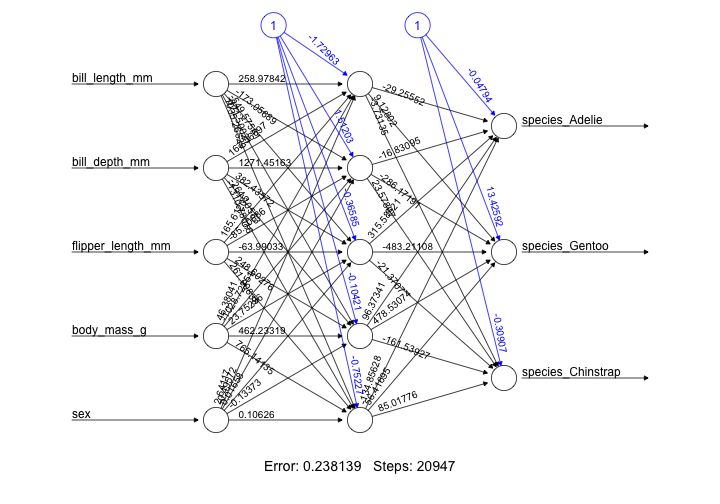

### Fitting a Neural Network using tidymodels and parsnip

```r
library(tidymodels)
library(parsnip)

model.spec =
  parsnip::mlp() %>%
  parsnip::set_engine("nnet") %>%
  parsnip::set_mode("classification")

parsnip.model =
  model.spec %>%
  parsnip::fit_xy(
    x = penguins4.train[,feature.names],
    y = penguins4.train$species %>% factor()
  )
```

### Model Evaluation

```r
# calculate accuracy on training set
train.probabilities = predict(
  parsnip.model, new_data = penguins4.train,
  type = "prob"
)

# ensure columns are in the right order!
train.predictions = max.col(
  train.probabilities[,
  sort(colnames(train.probabilities))]
)
train.true.values = max.col(
  penguins4.train[,dummy.cols]
  [,sort(dummy.cols)]
)
print(paste(
  "Train Accuracy:",
  round(100*mean(train.predictions == train.true.values,
        na.rm = TRUE)), "%"))
```

```
[1] "Train Accuracy: 96 %"
```

[output not shown]

[figure not shown]

### Cross Validation

- Cross validation can be used to pick the optimal number of hidden nodes
- Possible rule of thumb: between 1 and the number of input variables (other rules of thumb also exist)
- k-fold cross validation: split data into k folds. For each fold, train on k-1 folds, test on the kth fold
- Choose hidden layer with best average predictive performance across folds (such as Mean Squared Error)
- Other types of cross validation: leave-one-out, Monte Carlo cross validation
- Many packages automate this process!

[figure not shown]

### Cross Validation

```r
cv = function(data, hidden, n.folds = 2, formula, feature.names, output.names)
{
  # split data into 'folds' for cross validation
  fold.size = floor(nrow(data)/n.folds)
  category = NULL
  for(k in 1:n.folds){
    category = c(category, rep(k, fold.size))
  }
```

### Cross Validation

```r
  # we often have rounding errors (i.e. if we have 10 folds and
  # the number of rows is not divisible by 10)
  # so randomly assign the leftover rows to different folds
  if(length(category) != nrow(data))
  {
    extra.length = nrow(data) - length(category)
    extra = sample(seq(1, n.folds), extra.length)
    category = c(category, extra)
  }
  data$cv.fold = sample(category)
```

### Cross Validation

```r
  mse = rep(NA, n.folds)
  for(k in 1:n.folds)
  {
    # extra training/test data for this fold
    train.cv = data[data$cv.fold != k,]
    test.cv = data[data$cv.fold == k,]

    # the algorithm starts out with a random set of weights
    # occasionally it starts with suboptimal weights and does not converge
    # within the allowed time (maximum steps). Rather than increasing
    # the max number of steps, which would slow down the script,
    # I retry the model until it converges
    attempts = 0
    model.cv = NULL
    while( is.null(model.cv) & attempts <= 10)
    {
      model.cv = try(neuralnet(formula, train.cv, hidden = hidden, linear.output = FALSE))
      attempts = attempts + 1
    }
```

### Cross Validation

```r
    # calculate Mean Squared Error
    test.predictions = max.col(predict(model.cv, test.cv[,feature.names]))
    test.true.values = max.col(test.cv[,output.names])
    mse[k] = sum((test.predictions - test.true.values)^2)/nrow(test.cv)
  }
  return(mean(mse))
}
```

### Cross Validation

```r
test.size = function(data, n.folds, formula, feature.names, output.names)
{
  hidden.values = seq(1, length(feature.names))
  n.values = length(hidden.values)
  mse.all = rep(NA, n.values)
  for(i in 1:n.values)
  {
    mse.all[i] = cv(
      data, hidden.values[i], n.folds,
      formula, feature.names, output.names)
  }
  best = which.min(mse.all)
  return(hidden.values[best])
}
```

### Cross Validation

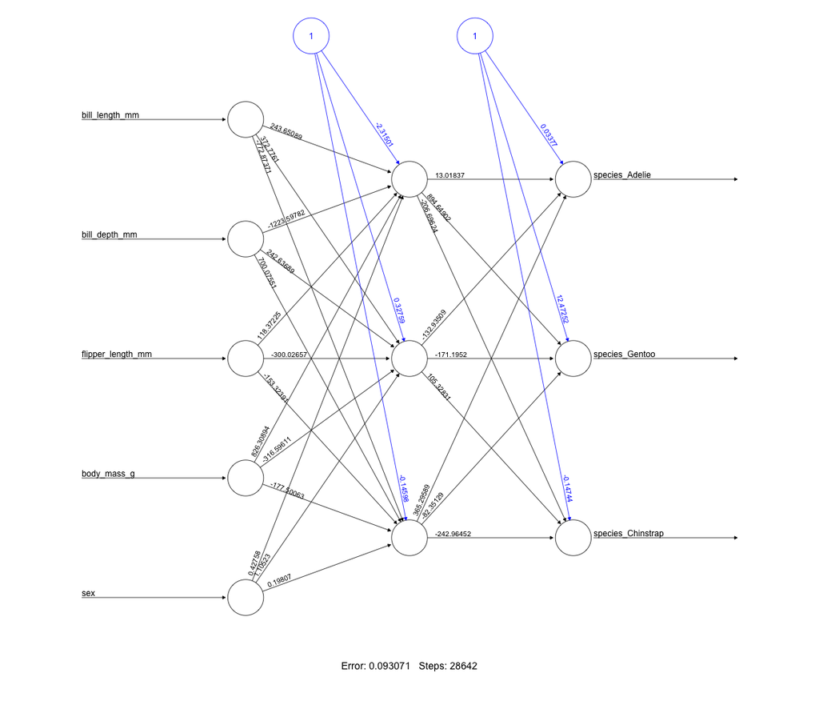

[figure not shown]

Part II: Using Debugging and Profiling Tools

[figure not shown]

### Debug on Error

- Tools > Global Options > Advanced > uncheck “Use debug error handler only when my code contains errors”
- Debug > On Error > Break in Code
- Optional: turn warnings into errors

```r
options(warn = 2)
```

### Debug Example

```r
foo = function(x){
  if(x > 0)
  {
    salutation = "Hello"
  } else
  {
    salutation = "Goodbye"
  }
  print(salutation)
}
foo(x = log(-1))
```

### Debug Tool

[figure not shown]

### Traceback

[figure not shown]

### R Debug

- Built-in tools in Rstudio to help you debug your code
- Enter debug mode at a certain line, on error, or when a particular function executes
- s: step into function, n: execute next statement
- f: finish function/loop, c: continue running
- Q: quit
- *Most important function*: recover(): steps out to allow you to enter a different function/level
- Note: in base R, same functionality by using functions like browser(), trace(), recover()

### R Profiler

- Built-in tools in Rstudio to help you identify slow or memory intensive parts of your code
- Allows you to easily compare speed when you modify code
- Note: in base R, same functionality by using functions like Rprof(), profr library

### Comparing Scripts

[figure not shown]

### References

- [Classification with Neural Networks](https://www.r-bloggers.com/multilabel-classification-with-neuralnet-package/)
- [Customizing R Presentations](https://rstudio-pubs-static.s3.amazonaws.com/27777_55697c3a476640caa0ad2099fe914ae5.html)
- [Dummies' Introduction to Neural Networks](https://medium.com/technologymadeeasy/for-dummies-the-introduction-to-neural-networks-we-all-need-c50f6012d5eb)
- [Cross Validation for selecting hidden node number](https://firsttimeprogrammer.blogspot.com.au/2015/09/selecting-number-of-neurons-in-hidden.html)
- [Deep Learning 101](https://beamandrew.github.io/deeplearning/2017/02/23/deep_learning_101_part1.html)
- [Debugging with Rstudio](https://support.rstudio.com/hc/en-us/articles/205612627-Debugging-with-RStudio)

### About me

- B.A. in Statistics from Harvard
- 3 years in industry (data scientist and software engineer at an education analytics company)
- Ph.D. in Statistics from Harvard
- Starting soon as faculty at University of New South Wales
- CRAN package for calculating power for experiments: https://github.com/MDRCNY/PUMP

Connect with me!

- Twitter: https://twitter.com/stats_hunter
- LinkedIn: https://www.linkedin.com/in/kristenbhunter/

Questions?

[figure not shown]

Slides available: github.com/kristenbhunter/presentations/RLadiesUrmia2022